# One weird trick to get 33% off Paspaley

Rohan

01/01/2019

# Overview

# Introduction

Paspaly make the best pearl jewelry in the world. Unfortunately it’s priced accordingly so actual Paspaley purchases are somewhat rare for me, but isn’t half the fun of luxury products comtemplating them? That said, there’s only so much time that I could spend looking at photos of pearls before I began to wonder about their pricing strategy, so I scraped the website on Boxing Day 2017, and again on Boxing Day 2018. After cleaning the data we can have a bit of a look at what’s going on.

The nice aspect of this project is that it’s a small-scale project that showcases a variety of data skills that I use in my academic life, but that rarely make it to the final paper such as: acquisition; cleaning; analysis; and communication. In this write-up I’m going to explain each step so that you can do you own analysis of a similar type. If you’d just like to see the project folder then it’s available on my GitHub page: https://github.com/RohanAlexander/paspaley. Note that I haven’t included the scraped html files there but if there’s something in the html that you think I haven’t taken advantage of then let me know and I can update the scripts.

# Data acquisition

There was an update to the Paspaly website at some point in the year where they moved away from Shopify. So I’ll just focus on the most recent version of the website here. The first step when acquiring data from a website is to check for an API. In this case, it doesn’t look like they have one. The next step is to look at the relevant robot.txt file: https://www.paspaley.com/robots.txt. In this case it doesn’t give us much information, but it helpfully provides a link to the XML sitemap: https://www.paspaley.com/pub/sitemap.xml.

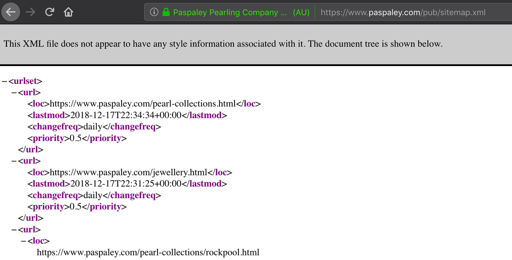

That appears to give us a nice list of the products on the website and their address so that we can get their details.

We can use the R package rvest to quickly grab the relevant information from this file.

Although the sitemap should be giving us everything, it’s worth seeing if we can follow the links to get any other information that’s missing.

Looking at the website, Paspaley organises the products by category (e.g. bracelet, earrings, etc) and also by collection (e.g. Monsoon, Rockpool, etc). Save each of those pages and we can then scrape the links for each of the individual products from them using

```r
library(purrr)
library(rvest)
library(tidyverse)


get_links <- function(file_to_look_at){
  content <- read_html(file_to_look_at) %>%
    html_nodes(".product-item-info") %>%
    html_nodes(".product") %>%
    html_nodes("a")

  link <- content %>%
    html_attr("href")

  text <- content %>%
    html_text(trim = TRUE)

  collection <- str_replace(file_to_look_at, "inputs/2018/lists/lists_by_collection/", "") %>%
    str_replace(".htm", "")

  return(tibble(link = link, text = text, collection = collection))
}


the_files <- c(
  "inputs/2018/lists/lists_by_collection/kimberley.htm",
  "inputs/2018/lists/lists_by_collection/lavalier.htm",
  "inputs/2018/lists/lists_by_collection/maxima.htm",
  "inputs/2018/lists/lists_by_collection/monsoon.htm",
  "inputs/2018/lists/lists_by_collection/rockpool.htm",
  "inputs/2018/lists/lists_by_collection/strand.htm",
  "inputs/2018/lists/lists_by_collection/touchstone.htm"
)


the_data <- purrr::map_df(the_files, get_links)


the_data <- the_data %>%
  mutate(product = str_replace_all(link, c("https://www.paspaley.com/pearl-collections/the-kimberley-bracelet/" = "",
                                           "https://www.paspaley.com/pearl-collections/lavalier/" = "",
                                           "https://www.paspaley.com/pearl-collections/maxima/" = "",
                                           "https://www.paspaley.com/pearl-collections/monsoon/" = "",
                                           "https://www.paspaley.com/pearl-collections/rockpool/" = "",
                                           "https://www.paspaley.com/pearl-collections/strands/" = "",
                                           "https://www.paspaley.com/pearl-collections/touchstone/" = "")),
         year = 2018)

write_csv(the_data, "outputs/misc/2018_links_from_collections.csv")
```

You can use a similar script to get the categories. Comparing the two indicates that the XML had a handful of products that were not part of a collection or a category, but not vice versa, so no worries.

Now that we have the list of the products that we’d like details about, we need to get the the page for each product.

```r
library(rvest)
library(tidyverse)

the_data <- read_csv("outputs/2018_links_from_categories.csv")

for (i in 1:length(the_data$link)) {
  product_data <- read_html(the_data$link[i])
  product_name <- str_replace_all(the_data$link[i], "https://www.paspaley.com/jewellery/", "")
  product_name <- str_replace_all(product_name, "/", "-")
  name_of_file <- paste0("inputs/2018/products/", product_name, ".html")
  write_html(product_data, file = name_of_file)

  print(paste(
    "Done with file number",
    i,
    "of",
    length(the_data$link),
    "at",
    Sys.time()
  ))  # Helpful updating for when running it on all the records
  Sys.sleep(60) # Space requests by 60 seconds.
}


# Clean up
rm(i, name_of_file, product_data, product_name)
```

# Data cleaning

In the last section we downloaded the pages for each of the Paspaley products that we could find on the website. The first step to being able to analyse the data is to transform it in a format that we’re more used to, such as a table.

So the task is to go through the html for each product and find the information that we are interested in: Name; Price; SKU; and Description. We’re going to be using the description to get some additional information that isn’t nicely laid out, such as the type of gold. The SKU is a unique identifier that will let us link products between years.

```r
library(purrr) # Makes it easier to do the same thing to many files
library(rvest) # Goes trhough the html tags and finds what we are looking for
library(tidyverse)

get_product_data <- function(file_to_look_at){
  # file_to_look_at <- c("inputs/2018/products/pearl-earrings-diamond-touchstone-earrings-12mm-oval-yellow-gold.html")
  # When I'm writing and testing a function I tend to insert one of the files manually here. I'm sure there's better ways to do this but this seems to work. (I normally delete it before showing anyone!)

  content <- read_html(file_to_look_at) %>% # read_html is an equivalent to, say, read_csv but for html files.
    html_nodes(".product-info-main") # Here we specify which set of nodes we are interested in. These are the ones that have to do with the products. You need to have a look at the html to work this out and it tends to be a bit of trial an error.

    name <- content %>%
      html_nodes(".base") %>% # Focus on the node that has the name
      html_text(trim = TRUE) # This gets the text from that node - depending on what type of information you're interested in, it might not be needed.

    description <- content %>%
      html_nodes(".short-description") %>%
      html_text(trim = TRUE)

    description <- ifelse(is_empty(description), "none", description) # Just in case they don't have a description we don't want an error.

    flowerydescription <- content %>%
      html_nodes(".description") %>%
      html_text(trim = TRUE) # Some of the products have extra descriptions.

    flowerydescription <- ifelse(is_empty(flowerydescription), "none", flowerydescription)

    availability <- content %>%
      html_nodes(".stock") %>%
      html_text(trim = TRUE)

    sku <- content %>%
      html_nodes(".sku") %>%
      html_text(trim = TRUE)

    price <- content %>%
      html_nodes(".price") %>%
      html_text(trim = TRUE)

  return(tibble(
    name = name,
    description = description,
    flowerydescription = flowerydescription,
    availability = availability,
    sku = sku,
    price = price
    )) # Here we gather everything into a table. Purrr will automatically combine the tables for each of the products.
}


products <- list.files("inputs/2018/products", full.names = TRUE) # Return a list of the the files. Handy when there are many files, otherwise just a manual list works too. You can also specify the file type or that they start/end with certain words etc. Very handy.

names(products) <- list.files("inputs/2018/products") %>%
  gsub(pattern = ".html$", replacement = "") # This just allows us to include the names of the files in the eventual full table. You can make this better so that it doesn't list the files again (dangerous in case the order changes between listings), but for this project it's fine.

dataset <- purrr::map_df(products, # List of files
                         get_product_data, # Function to apply to each file
                         .id = "product" # Name of the column with the filenames (otherwise the content is just 1, 2, 3,...)
                         ) #

write_csv(dataset, "outputs/2018_dataset.csv")
```

We now have the data into a table that we can work with. Unlike the usual teaching datasets, we need to clean the data so that we can apply our usual methods to them. For instance, many of the prices aren’t an integer because they have AUD in front of them and some of the SKUs have SKU in front, but not all. (I’ve not really gone into detail about the 2017 data, and it sort of just apepars here now, but it was a similar process of getting it to here.)

```r
library(stringr) # Used to make regular expressions less confronting
library(tidyverse)


# Read in the datasets
the_2018_data <- read_csv("outputs/data/2018_dataset.csv")
the_2017_data <- read_csv("outputs/data/2017_dataset.csv")


# Combine the datasets
the_2018_data$year = 2018
the_2017_data$year = 2017
the_data <- rbind(the_2017_data, the_2018_data)
rm(the_2017_data, the_2018_data)


# Fix price
the_data$price <- ?str_replace_all(the_data$price, "[\r\n]" , "") %>%
  str_replace(".*\\$", "") # Get rid of the "Starting from..." ones - we just want a number - this is an issue with some of the 2017 ones

the_data$price <- str_replace_all(the_data$price, c("AUD " =  "", "," = "")) %>%
  as.integer() # Convert to a integer - the 2018 ones start with AUD so remove that first


# Fix SKU
the_data$sku <- str_replace_all(the_data$sku, c("SKU    " =  "")) # The 2018 ones actually start with "SKU" but we just want the number
```

We’d like to be able to group the analysis by the type of item it is (necklace, earrings, etc) and by the collection (Rockpool). We can use our earlier checks to be able to get the category that Paspaley has put each item into. And we can look at the names and descriptions fields for the ones that were missing.

```r
# Identify the collection
# First start by using the collections in the website
links_by_collection_2018 <- read_csv("outputs/misc/2018_links_from_collections.csv")
links_by_collection_2017 <- read_csv("outputs/misc/2017_links_from_collections.csv")
links_by_collection <- rbind(links_by_collection_2017, links_by_collection_2018) %>%
  select(collection, product, year)
rm(links_by_collection_2017, links_by_collection_2018)

the_data <- the_data %>%
  mutate(for_matching = str_replace_all(product, c("pearl-accessories-" = "",
                                                   "pearl-bracelets-" = "",
                                                   "pearl-clasps-" = "",
                                                   "pearl-earrings-" = "",
                                                   "pearl-necklaces-" = "",
                                                   "pearl-rings-" = "")))

the_data <- the_data %>%
  left_join(links_by_collection, by = c("year" = "year",
                                        "for_matching" = "product"))

rm(links_by_collection)

# Now, by looking at the content if it wasn't identified already
the_data <- the_data %>%
  mutate(collection_brute_force = case_when(
    str_detect(product, "kimberley") ~ "kimberley",
    str_detect(product, "lavalier") ~ "lavalier",
    str_detect(product, "maxima") ~ "maxima",
    str_detect(product, "monsoon") ~ "monsoon",
    str_detect(product, "pearls-my-way") ~ "pearls_my_way",
    str_detect(product, "rockpool") ~ "rockpool",
    str_detect(product, "strand") ~ "strand",
    str_detect(product, "gold-keshi-rhapsody") ~ "strand", # outlier
    str_detect(product, "touchstone") ~ "touchstone",
    TRUE ~ "other"
    ))


the_data <- the_data %>%
  mutate(collection = if_else(is.na(collection), collection_brute_force, collection)) %>%
  select(-collection_brute_force)

the_data$collection[the_data$collection == "pearls_my_way"] <- "Pearls My Way"
the_data$collection <- str_to_title(the_data$collection , locale = "en")


# Category
# Again, as before, looking at the website content first
links_by_categories_2018 <- read_csv("outputs/misc/2018_links_from_categories.csv")
links_by_categories_2017 <- read_csv("outputs/misc/2017_links_from_categories.csv")
links_by_categories <- rbind(links_by_categories_2017, links_by_categories_2018) %>%
  select(category, product, year)
rm(links_by_categories_2017, links_by_categories_2018)

the_data <- the_data %>%
  left_join(links_by_categories, by = c("year" = "year",
                                        "for_matching" = "product"))

the_data <- the_data %>%
  mutate(category_brute_force = case_when(
    str_detect(product, "accessories") ~ "Accessory",
    str_detect(product, "bracelets") ~ "Bracelet",
    str_detect(product, "clasps") ~ "Clasp",
    str_detect(product, "earrings") ~ "Earrings",
    str_detect(product, "necklaces") ~ "Necklace",
    str_detect(product, "rings") ~ "Ring",
    str_detect(product, "petite-circle-strand") ~ "Necklace",
    str_detect(product, "baroque-strand") ~ "Necklace",
    str_detect(product, "gold-keshi-rhapsody") ~ "Necklace",
    str_detect(product, "keshi-rope-strand-of-the-harvest") ~ "Necklace",
    TRUE ~ "Other"
  ))

the_data <- the_data %>%
  mutate(category = if_else(is.na(category), category_brute_force, category)) %>%
  select(-category_brute_force)

the_data$category[the_data$category == "necklaces_and_pendants"] <- "Necklaces and Pendants"
the_data$category[the_data$category == "Necklace"] <- "Necklaces and Pendants"
the_data$category[the_data$category == "necklaces"] <- "Necklaces and Pendants"

the_data$category <- str_to_title(the_data$category , locale = "en")
```

We think that there might be a difference between keshi pearls and non-keshi pearls. (My knowledge here is based solely on what Paspaley salespeople have told me, but I think that Keshi form naturally so they don’t have a little round ball in the middle of them, whereas non-keshi have been implanted and then the oyster coats it with the pearl substance.) We’d also like to pull out the shape of the pearl (round, triangle, etc), and the metal (white gold, rose gold, etc).

```r
# Identify whether keshi pearl
the_data <- the_data %>%
  mutate(keshi = case_when(
    str_detect(product, "keshi") ~ TRUE,
    str_detect(name, "Keshi") ~ TRUE,
    str_detect(description, "Keshi") ~ TRUE,
    str_detect(description, "keshi") ~ TRUE,
    TRUE ~ FALSE
  ))


# Metal
the_data <- the_data %>%
  mutate(metal = case_when(
    str_detect(name, "White Gold") ~ "White gold",
    str_detect(name, "Yellow Gold") ~ "Yellow gold",
    str_detect(name, "Rose Gold") ~ "Rose gold",
    str_detect(name, "Platinum") ~ "Platinum",
    str_detect(description, "white gold") ~ "White gold",
    str_detect(description, "yellow gold") ~ "Yellow gold",
    str_detect(description, "rose gold") ~ "Rose gold",
    str_detect(description, "platinum") ~ "Platinum",
    TRUE ~ "Other"
  ))

# Pearl type
the_data <- the_data %>%
  mutate(description_lowered = str_to_lower(description)) %>%
  mutate(pearl_type = case_when(
    str_detect(description_lowered, "mother-of-pearl") ~ "Mother of pearl",
    str_detect(description_lowered, "mother of pearl") ~ "Mother of pearl",
    str_detect(description_lowered, "triangle pearl") ~ "Triangle",
    str_detect(description_lowered, "round pearl") ~ "Round",
    str_detect(description_lowered, "button pearl") ~ "Button",
    str_detect(description_lowered, "semi-round pearl") ~ "Semi-round",
    str_detect(description_lowered, "drop pearl") ~ "Drop",
    str_detect(description_lowered, "circle pearl") ~ "Circle",
    str_detect(description_lowered, "oval pearl") ~ "Oval",
    str_detect(description_lowered, "round australian south sea pearl") ~ "Round",
    str_detect(description_lowered, "round paspaley pearls") ~ "Round",
    str_detect(description_lowered, "oval drop australian south sea pearls") ~ "Oval",
    str_detect(description_lowered, "oval australian south sea pearl") ~ "Oval",
    str_detect(description_lowered, "button australian south sea pearl") ~ "Button",
    TRUE ~ "Unsure"
  )) %>%
  select(-description_lowered)
```

Finally, in anything that is written there are always typos and mistakes that fresh eyes notice, but that the author could read a thousand times and miss. So we’d like to fix a bit of the website content, so that they don’t continue into our dataset (instead we can make new mistakes!).

```r
# Fix typos and inconsistencies
the_data$description <- str_replace_all(the_data$description, "in18kt", "in 18kt")
the_data$description <- str_replace_all(the_data$description, "18ct white gold", "18kt white gold") # Google says that ct refers to weight and kt refers to purity, so should be 18kt white gold etc?
the_data$description <- str_replace_all(the_data$description, "18ct yellow gold", "18kt yellow gold")
the_data$description <- str_replace_all(the_data$description, "pearl  bracelet", "pearl bracelet")
the_data$description <- str_replace_all(the_data$description, "feturing", "featuring")
the_data$description <- str_replace_all(the_data$description, "Papsaley", "Paspaley") # Frankly, I'm suprised this didn't happen more often
the_data$name <- str_replace_all(the_data$name, "Oval  - Yellow Gold", "Oval - Yellow Gold")
the_data$name <- str_replace_all(the_data$name, "Baroque  - White Gold", "Baroque - White Gold")
the_data$name <- str_replace_all(the_data$name, "Oval  - White Gold", "Oval - White Gold")
the_data$description <- str_replace_all(the_data$description, "extrodinary", "extraordinary")
the_data$description <- str_replace_all(the_data$description, "feauturing", "featuring")
the_data$description <- str_replace_all(the_data$description, "fourty-eight", "forty-eight")
the_data$description <- str_replace_all(the_data$description, "featruing", "featuring")
the_data$description <- str_replace_all(the_data$description, "fotry-eight", "forty-eight")
the_data$description <- str_replace_all(the_data$description, "suprisingly", "surprisingly")
the_data$description <- str_replace_all(the_data$description, "\\.(?=[:upper:][:lower:])", ". ") # There's a bunch with no space following the full stop at the end of the sentence.
the_data$description <- str_replace_all(the_data$description, "\\.(?=A)", ". ")
the_data$description <- str_replace_all(the_data$description, "Freah", "Fresh")
the_data$description <- str_replace_all(the_data$description, "ninty", "ninety")
the_data$description <- str_replace_all(the_data$description, "Introducing Pearls My Way\\. Tailor your look by choosing your preferred Australian South Sea pearls and earring hooks in your favourite shade of gold. Add some colour to your earrings with a variety of precious gemstones including rubies and diamonds\\. Prefer to create your own Pearls My Way earrings\\? Contact the Personal Shopper or visit your nearest boutique. Personal Shopper Recommendation:", "")
the_data$description <- str_replace_all(the_data$description, "Introducing Pearls My Way\\. Tailor your look by choosing your preferred Australian South Sea pearls and earring hooks in your favourite shade of gold\\. Add some colour to your earrings with a variety of precious gemstones including rubies and diamonds\\. Prefer to create your own Pearls My Way earrings\\? Contact Personal Shopper or visit your nearest boutique\\. Personal Shopper Recommendation:", "")

the_data <- the_data[-160,] # For some reason Odyssey Swap is in there twice for 2017. I know you're not meant to do the removal this way, but here we are.

# Save the data
write_csv(the_data, "outputs/data/cleaned_dataset.csv")
```

# Data analysis

This is just a ‘fun’ analysis - we don’t have all the data (only what they put on the website). If you just want the cleaned dataset then you can get it here: https://github.com/RohanAlexander/paspaley/blob/master/outputs/data/cleaned_dataset.csv

The first thing that jumps out is that the number of items on the website has decreased from 276 in 2017 to 179 in 2018.

```r
# Number per year
the_data %>% group_by(year) %>% count()
```

```
## # A tibble: 2 x 2
## # Groups:   year [2]
##    year     n
##   <dbl> <int>
## 1  2017   276
## 2  2018   179
```

That’s despite the fact that Paspaley introduced a whole new collection - Monsoon - this year which has 33 products on the website. Looking at the counts by collection suggests what is going on - there has been a decrease in the number of ‘Other’ products. For instance, in 2017 the website had gift vouchers, but these aren’t on the website (or at least I couldn’t find them) in 2018.

```r
# Number per year per collection
the_data %>%
  group_by(year, collection) %>%
  count() %>%
  spread(year, n)
```

```
## # A tibble: 9 x 3
## # Groups:   collection [9]
##   collection    `2017` `2018`
##   <chr>          <int>  <int>
## 1 Kimberley          5      6
## 2 Lavalier          26     10
## 3 Maxima            36     27
## 4 Monsoon           NA     33
## 5 Other            129     57
## 6 Pearls My Way     13      6
## 7 Rockpool          28     20
## 8 Strand            11      4
## 9 Touchstone        28     16
```

In general, it’s clear that Paspaley has changed how they are using their website. It’s gone from acting as a place of commerce (e.g. being able to buy gift vouchers on it) to being something that feels more about allowing people to engage with the brand in a less financial way, perhaps as a complement to their Instagram account, but you still go into the stores when you want to buy.

Based on the SKUs, there are 77 products that are on the 2017 and 2018 versions of the website.

```r
product_in_both_years <- the_data %>%
  select(sku, year, price) %>%
  group_by(sku) %>%
  spread(key = year, value = price) %>%
  rename(price_in_2017 = `2017`, price_in_2018 = `2018`) %>%
  filter(!is.na(price_in_2018) & !is.na(price_in_2017)) %>%
  left_join(the_data[the_data$year == 2018,]) %>%
  select(sku, product, collection, category) %>%
  ungroup()
product_in_both_years %>%
  count(category)
```

```
## # A tibble: 6 x 2
##   category                   n
##   <chr>                  <int>
## 1 Accessories                4
## 2 Bracelets                 12
## 3 Clasps                     5
## 4 Earrings                  22
## 5 Necklaces And Pendants    29
## 6 Rings                      5
```

```r
product_in_both_years %>%
  count(collection)
```

```
## # A tibble: 7 x 2
##   collection        n
##   <chr>         <int>
## 1 Kimberley         3
## 2 Lavalier          7
## 3 Maxima           16
## 4 Other            24
## 5 Pearls My Way     2
## 6 Rockpool         16
## 7 Touchstone        9
```

The most common category of product to be on the website in both years is necklaces and pendants, followed by earrings. The distribution between the collections is also surprising, with other being the most popular, but Maxima and Rockpool being next.

Even though Paspaley has a lot of products at that it doesn’t sell through the website, the prices that are shown on the website are still generally fairly high!

```r
library(scales) # Just used to get away from scientific notation in the last line.
```

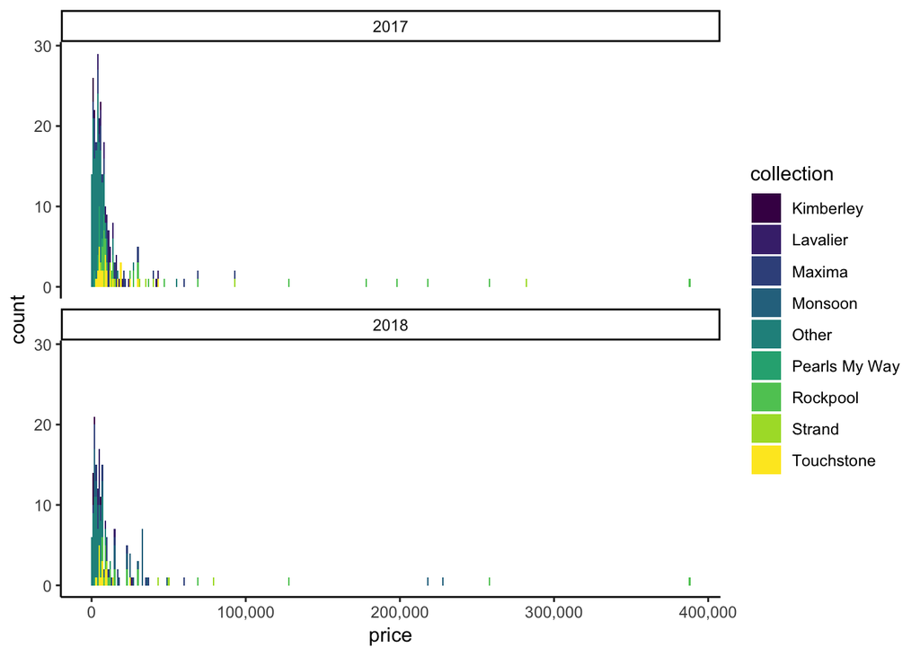

```r
ggplot(data = the_data, aes(x = price, fill = collection)) +
  geom_histogram(binwidth = 1000) +
  facet_wrap(vars(year), nrow = 2) +
  theme_classic() +
  scale_fill_viridis_d() +
  scale_x_continuous(labels = comma)
```

There is a large skew - in 2018 there were five products with a price over $100,000; down from seven in 2017. Interestingly if we focus on products that have a price less than $50,000 we again see this skew, although at this less expensive (still way too expensive for me) level it’s being driven by the ‘other’ collection These tends to be products such as clasps or chains.

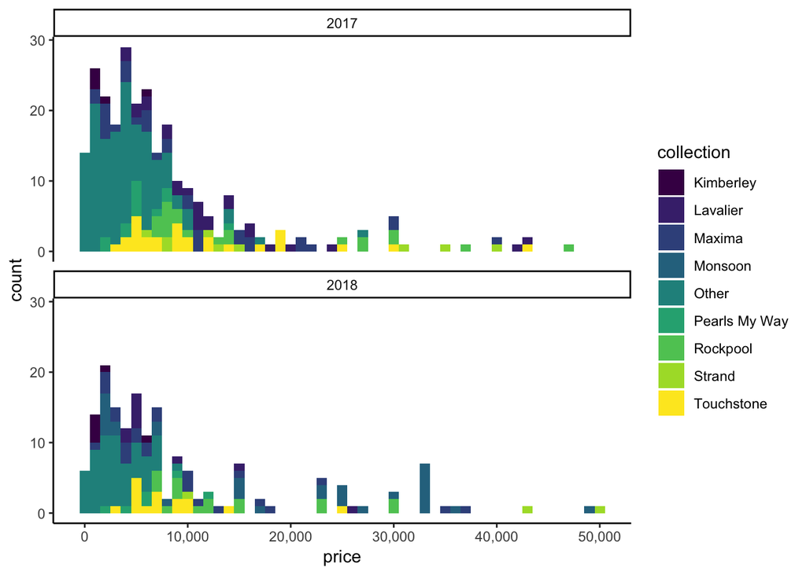

```r
ggplot(data = the_data[the_data$price < 50000,], aes(x = price, fill = collection)) +
  geom_histogram(binwidth = 1000) +
  facet_wrap(vars(year), nrow = 2) +
  theme_classic() +
  scale_fill_viridis_d() +
  scale_x_continuous(labels = comma)
```

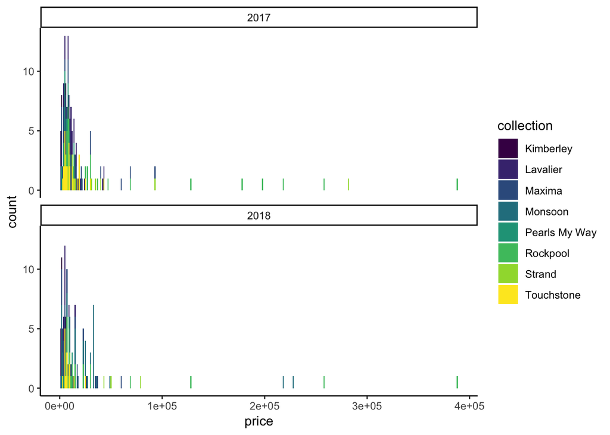

```r
ggplot(data = the_data[the_data$collection != "Other",], aes(x = price, fill = collection)) +
  geom_histogram(binwidth = 1000) +
  facet_wrap(vars(year), nrow = 2) +
  theme_classic() +
  scale_fill_viridis_d()
```

We can use a boxplot to foxus on the distribution by collection.

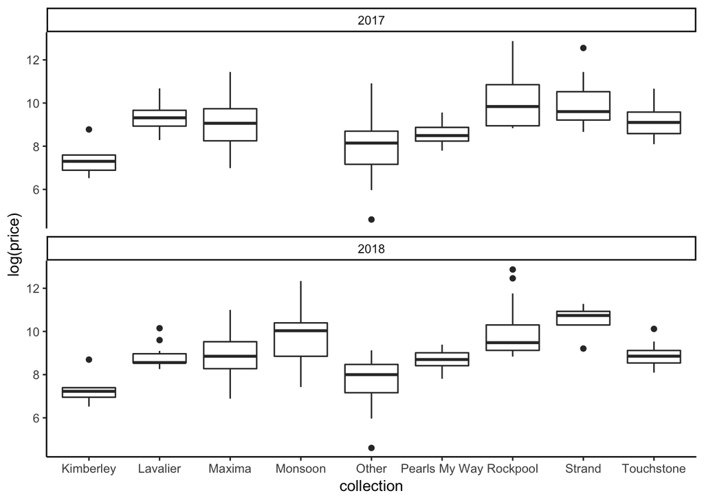

```r
ggplot(data = the_data, aes(collection, log(price))) +
  geom_boxplot() +
  facet_wrap(vars(year), nrow = 2) +
  theme_classic()
```

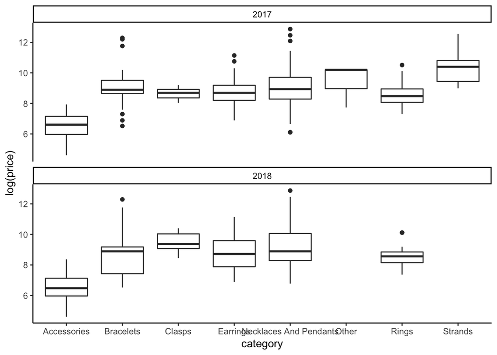

```r
ggplot(data = the_data, aes(category, log(price))) +
  geom_boxplot() +
  facet_wrap(vars(year), nrow = 2) +
  theme_classic()
```

# Weaknesses

An obvious weakness of the analysis is that it’s just based on what I could find on the website. With a better dataset we could do more interesting analysis and be more confident in our results.